# XGBoost for Instacart

Boriss

July 10, 2017

```r
path_main = "U:/BBB/PROPACAD/"
path_data = paste0(path_main, 'DATA/')
path_subm = paste0(path_main, 'SUBM/')

orders      <- fread( paste0(path_data, 'orders.csv') )
```

```
##
Read 67.5% of 3421083 rows
Read 3421083 rows and 7 (of 7) columns from 0.101 GB file in 00:00:03
```

```r
products    <- fread( paste0(path_data, 'products.csv'             ) )
ordert      <- fread( paste0(path_data, 'order_products__train.csv') )
orderp      <- fread( paste0(path_data, 'order_products__prior.csv') )
```

```
##
Read 0.0% of 32434489 rows
Read 30.3% of 32434489 rows
Read 60.6% of 32434489 rows
Read 91.0% of 32434489 rows
Read 32434489 rows and 4 (of 4) columns from 0.538 GB file in 00:00:11
```

```r
aisles      <- fread( paste0(path_data, 'aisles.csv'               ) )
departments <- fread( paste0(path_data, 'departments.csv'          ) )

ordert_tmp = head( ordert, n = 20 )
```

```r
#path <- "./DATA"

#orders      <- fread(file.path(path,'orders.csv'               ) )
#products    <- fread(file.path(path,'products.csv'             ) )
#ordert      <- fread(file.path(path,'order_products__train.csv') )
#orderp      <- fread(file.path(path,'order_products__prior.csv') )
#aisles      <- fread(file.path(path,'aisles.csv'               ) )
#departments <- fread(file.path(path,'departments.csv'          ) )
```

```r
# Reshape data ------------------------------------------------------------
aisles$aisle           <- as.factor(aisles$aisle)
departments$department <- as.factor(departments$department)
orders$eval_set        <- as.factor(orders$eval_set)
products$product_name  <- as.factor(products$product_name)
```

Substitute aisle_id and department_id with their names from aisles and department Dataframe products before

```r
head( products )
```

```
##    product_id
## 1:          1
## 2:          2
## 3:          3
## 4:          4
## 5:          5
## 6:          6
##                                                         product_name
## 1:                                        Chocolate Sandwich Cookies
## 2:                                                  All-Seasons Salt
## 3:                              Robust Golden Unsweetened Oolong Tea
## 4: Smart Ones Classic Favorites Mini Rigatoni With Vodka Cream Sauce
## 5:                                         Green Chile Anytime Sauce
## 6:                                                      Dry Nose Oil
##    aisle_id department_id
## 1:       61            19
## 2:      104            13
## 3:       94             7
## 4:       38             1
## 5:        5            13
## 6:       11            11
```

and after

```r
products <- products %>%
  inner_join(aisles) %>% inner_join(departments) %>%
  select(-aisle_id, -department_id)
rm(aisles, departments) # remove (aisles, departments) from memory
head( products)
```

```
##   product_id
## 1          1
## 2          2
## 3          3
## 4          4
## 5          5
## 6          6
##                                                        product_name
## 1                                        Chocolate Sandwich Cookies
## 2                                                  All-Seasons Salt
## 3                              Robust Golden Unsweetened Oolong Tea
## 4 Smart Ones Classic Favorites Mini Rigatoni With Vodka Cream Sauce
## 5                                         Green Chile Anytime Sauce
## 6                                                      Dry Nose Oil
##                        aisle    department
## 1              cookies cakes        snacks
## 2          spices seasonings        pantry
## 3                        tea     beverages
## 4               frozen meals        frozen
## 5 marinades meat preparation        pantry
## 6           cold flu allergy personal care
```

### Add

```r
head( orders )
```

```
##    order_id user_id eval_set order_number order_dow order_hour_of_day
## 1:  2539329       1    prior            1         2                 8
## 2:  2398795       1    prior            2         3                 7
## 3:   473747       1    prior            3         3                12
## 4:  2254736       1    prior            4         4                 7
## 5:   431534       1    prior            5         4                15
## 6:  3367565       1    prior            6         2                 7
##    days_since_prior_order
## 1:                     NA
## 2:                     15
## 3:                     21
## 4:                     29
## 5:                     28
## 6:                     19
```

```r
head( ordert, n = 10 )
```

```
##     order_id product_id add_to_cart_order reordered
##  1:        1      49302                 1         1
##  2:        1      11109                 2         1
##  3:        1      10246                 3         0
##  4:        1      49683                 4         0
##  5:        1      43633                 5         1
##  6:        1      13176                 6         0
##  7:        1      47209                 7         0
##  8:        1      22035                 8         1
##  9:       36      39612                 1         0
## 10:       36      19660                 2         1
```

**match** returns a vector of the positions of (first) matches of its first argument in its second.

```r
ordert$order_id[1:10]
```

```
##  [1]  1  1  1  1  1  1  1  1 36 36
```

```r
#NB! orders contain order_id's in prior, train, test
#match(ordert$order_id[1:10], orders$order_id) returns indexes of order_id in ordert in orders

orders[ match(ordert$order_id[1:10], orders$order_id), ]
```

```
##     order_id user_id eval_set order_number order_dow order_hour_of_day
##  1:        1  112108    train            4         4                10
##  2:        1  112108    train            4         4                10
##  3:        1  112108    train            4         4                10
##  4:        1  112108    train            4         4                10
##  5:        1  112108    train            4         4                10
##  6:        1  112108    train            4         4                10
##  7:        1  112108    train            4         4                10
##  8:        1  112108    train            4         4                10
##  9:       36   79431    train           23         6                18
## 10:       36   79431    train           23         6                18
##     days_since_prior_order
##  1:                      9
##  2:                      9
##  3:                      9
##  4:                      9
##  5:                      9
##  6:                      9
##  7:                      9
##  8:                      9
##  9:                     30
## 10:                     30
```

### Add corresponding user_id to ordert

```r
ordert$user_id <- orders$user_id[ match(ordert$order_id, orders$order_id) ]
ordert_tmp1= head( ordert, n = 10 )
```

```r
head( orderp, n = 10 )
```

```
##     order_id product_id add_to_cart_order reordered
##  1:        2      33120                 1         1
##  2:        2      28985                 2         1
##  3:        2       9327                 3         0
##  4:        2      45918                 4         1
##  5:        2      30035                 5         0
##  6:        2      17794                 6         1
##  7:        2      40141                 7         1
##  8:        2       1819                 8         1
##  9:        2      43668                 9         0
## 10:        3      33754                 1         1
```

```r
head( orders, n = 10 )
```

```
##     order_id user_id eval_set order_number order_dow order_hour_of_day
##  1:  2539329       1    prior            1         2                 8
##  2:  2398795       1    prior            2         3                 7
##  3:   473747       1    prior            3         3                12
##  4:  2254736       1    prior            4         4                 7
##  5:   431534       1    prior            5         4                15
##  6:  3367565       1    prior            6         2                 7
##  7:   550135       1    prior            7         1                 9
##  8:  3108588       1    prior            8         1                14
##  9:  2295261       1    prior            9         1                16
## 10:  2550362       1    prior           10         4                 8
##     days_since_prior_order
##  1:                     NA
##  2:                     15
##  3:                     21
##  4:                     29
##  5:                     28
##  6:                     19
##  7:                     20
##  8:                     14
##  9:                      0
## 10:                     30
```

### Expand orders with detailed information per order from orderp

```r
orders_products     = orders %>% inner_join(orderp, by = "order_id")
orders_products_tmp = head(orders_products, n = 250 )
unique( orders_products$eval_set ) #check whether orders are only from prior
```

```
## [1] prior
## Levels: prior test train
```

```r
rm(orderp)
gc()
```

```
##             used   (Mb) gc trigger   (Mb)  max used   (Mb)
## Ncells    525848   28.1     940480   50.3    785098   42.0
## Vcells 196676218 1500.6  314142310 2396.8 294047164 2243.5
```

### Check how many unique products were ordered in prior

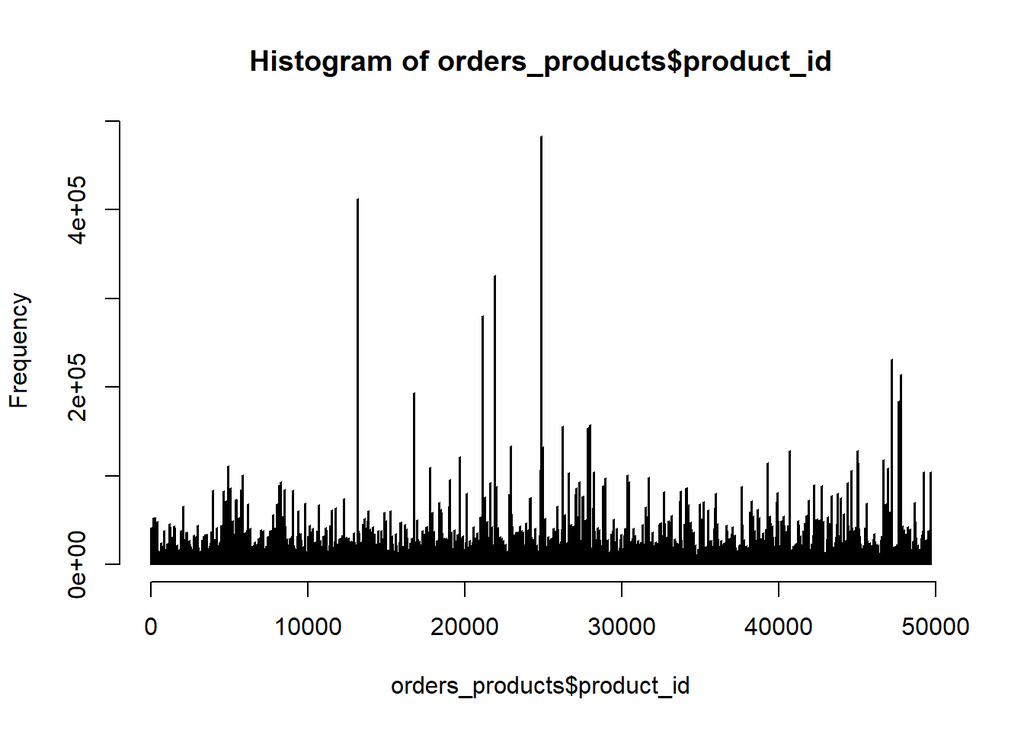

```r
hist( orders_products$product_id, breaks = 1000 )
```

```r
length( unique( orders_products$product_id ) )
```

```
## [1] 49677
```

```r
dim( products)
```

```
## [1] 49688     4
```

arrange {dplyr}: arrange(user_id, order_number, product_id) sorts orders_products in ascending order - first according to user_id - second according to order_number - third accorindg to product_id

mutate(product_time = row_number()): i.e. row_number(): equivalent to rank(ties.method = “first”) create a variable that tracks how many times each product_id was ordered by each user_id

```r
prd_tmp <- orders_products %>%
  arrange(user_id, order_number, product_id) %>%
  group_by(user_id, product_id) %>%
  mutate(product_time = row_number()) %>%
  ungroup()
head( prd_tmp, n = 40 )
```

```
## # A tibble: 40 x 11
##    order_id user_id eval_set order_number order_dow order_hour_of_day
##       <int>   <int>   <fctr>        <int>     <int>             <int>
##  1  2539329       1    prior            1         2                 8
##  2  2539329       1    prior            1         2                 8
##  3  2539329       1    prior            1         2                 8
##  4  2539329       1    prior            1         2                 8
##  5  2539329       1    prior            1         2                 8
##  6  2398795       1    prior            2         3                 7
##  7  2398795       1    prior            2         3                 7
##  8  2398795       1    prior            2         3                 7
##  9  2398795       1    prior            2         3                 7
## 10  2398795       1    prior            2         3                 7
## # ... with 30 more rows, and 5 more variables:
## #   days_since_prior_order <dbl>, product_id <int>,
## #   add_to_cart_order <int>, reordered <int>, product_time <int>
```

```r
prd_tmp2 = head( prd_tmp, n = 140 )
prd_tmp %>% filter( product_id == 196 ) %>% select(user_id, product_id, product_time) %>% head( n = 30 )
```

```
## # A tibble: 30 x 3
##    user_id product_id product_time
##      <int>      <int>        <int>
##  1       1        196            1
##  2       1        196            2
##  3       1        196            3
##  4       1        196            4
##  5       1        196            5
##  6       1        196            6
##  7       1        196            7
##  8       1        196            8
##  9       1        196            9
## 10       1        196           10
## # ... with 20 more rows
```

### Determine product characteristics:

- prod_orders: how many times a product_id was ordered by all users
- prod_reorders: how many times a product_id was reordered by all users
- prod_first_orders: number of times a product_id was ordered for the first time
- prod_second_order: number of times a product_id was ordered for the second time

```r
# Products ----------------------------------------------------------------
rm( prd_tmp, prd_tmp2 )

prd <- orders_products %>%
  arrange(user_id, order_number, product_id) %>%
  group_by(user_id, product_id) %>%
  mutate(product_time = row_number()) %>%
  ungroup() %>%
  group_by(product_id) %>%
  summarise(
    prod_orders        = n(),
    prod_reorders      = sum(reordered),
    prod_first_orders  = sum(product_time == 1),
    prod_second_orders = sum(product_time == 2)
  )
prd_tmp3 = head( prd, n = 40 )
```

### create several features

prod_reorder_probability - probability of first re-order prod_reorder_times - aka prd$prod_orders / prd$prod_first_orders as prd$prod_first_orders + prd$prod_reorders = aka rd$prod_orders see prd_tmp3 : inverse of share of prod_first_orders in prod_orders, if that share is close to one, then it is very likely that this product on average was bought only once prod_reorder_ratio - share of reorders in orders

```r
prd$prod_reorder_probability <- prd$prod_second_orders / prd$prod_first_orders
prd$prod_reorder_times       <- 1 + prd$prod_reorders  / prd$prod_first_orders
prd$prod_reorder_ratio       <- prd$prod_reorders      / prd$prod_orders

prd <- prd %>% select(-prod_reorders, -prod_first_orders, -prod_second_orders)

rm(products)
gc()
```

```
##             used   (Mb) gc trigger   (Mb)  max used   (Mb)
## Ncells    487463   26.1   16708522  892.4  20885653 1115.5
## Vcells 196454418 1498.9  568996620 4341.1 706506574 5390.3
```

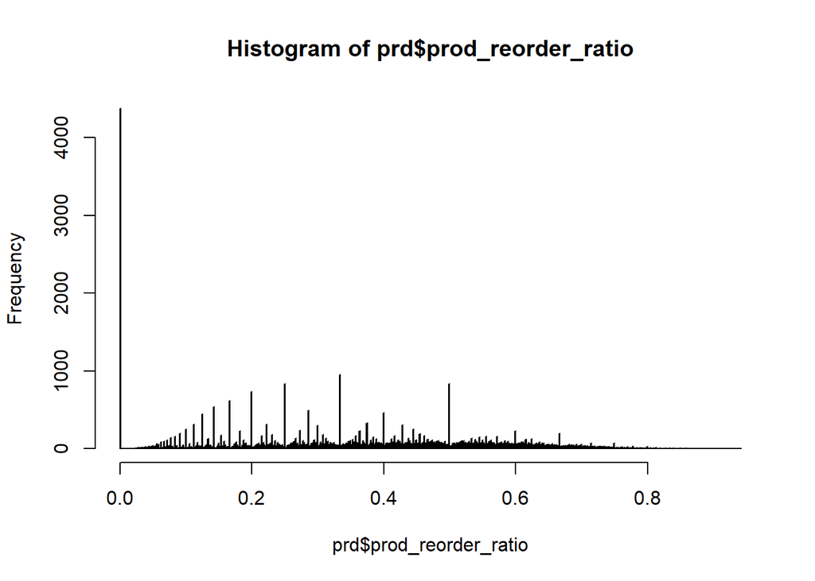

```r
prd_tmp4 = head( prd, n = 40 )

hist( prd$prod_reorder_ratio, breaks = 1000)
```

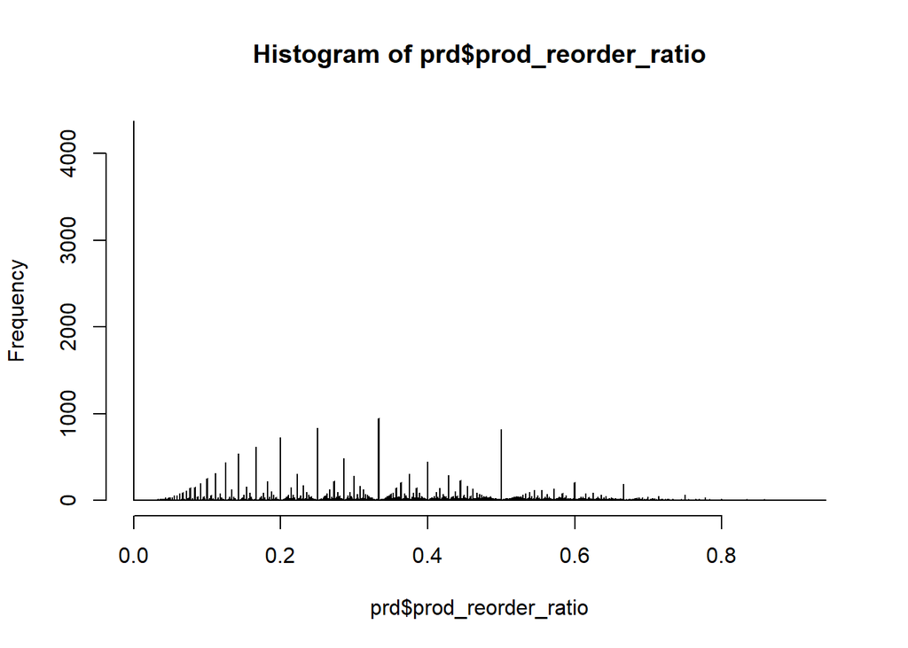

```r
hist( prd$prod_reorder_ratio, breaks = 5000)
```

```r
sum( prd$prod_reorder_ratio == 0)
```

```
## [1] 4372
```

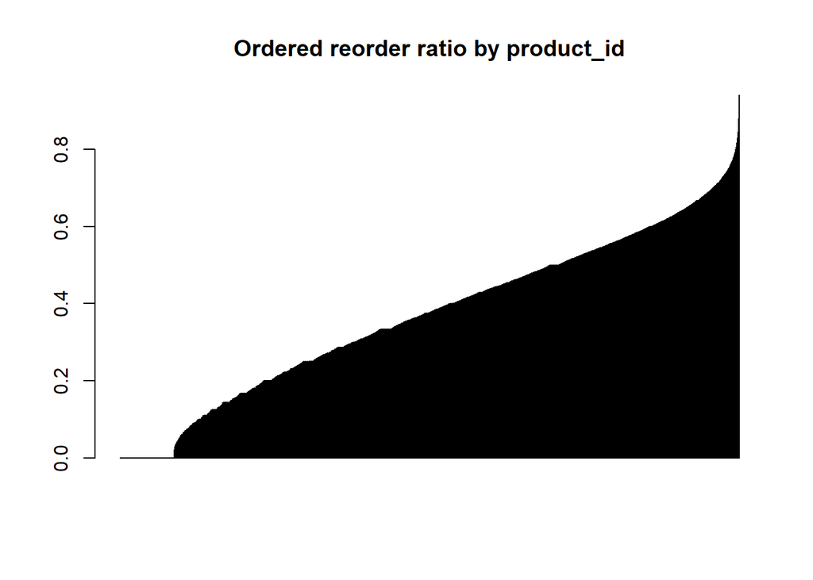

```r
barplot( prd$prod_reorder_ratio[ order( prd$prod_reorder_ratio ) ],
         main = "Ordered reorder ratio by product_id" )
```

```r
summary( prd$prod_reorder_ratio )
```

```
##    Min. 1st Qu.  Median    Mean 3rd Qu.    Max.
##  0.0000  0.2081  0.3766  0.3665  0.5293  0.9412
```

```r
# Products ----------------------------------------------------------------
prd <- orders_products %>%
  arrange(user_id, order_number, product_id) %>%
  group_by(user_id, product_id) %>%
  mutate(product_time = row_number()) %>%
  ungroup() %>%
  group_by(product_id) %>%
  summarise(
    prod_orders = n(),
    prod_reorders = sum(reordered),
    prod_first_orders = sum(product_time == 1),
    prod_second_orders = sum(product_time == 2)
  )

prd$prod_reorder_probability <- prd$prod_second_orders / prd$prod_first_orders
prd$prod_reorder_times <- 1 + prd$prod_reorders / prd$prod_first_orders
prd$prod_reorder_ratio <- prd$prod_reorders / prd$prod_orders

prd <- prd %>% select(-prod_reorders, -prod_first_orders, -prod_second_orders)

rm(products)
gc()
```

```
##             used   (Mb) gc trigger   (Mb)  max used   (Mb)
## Ncells    492575   26.4   16072180  858.4  20885653 1115.5
## Vcells 196464144 1499.0  546300755 4168.0 706506574 5390.3
```

## characteristics of users in prior set

- user_order_number : order_number per user
- user_period : how long a user_id was a customer
- user_mean_days_since_prior: average shopping frequency

```r
# Users -------------------------------------------------------------------
users <- orders %>%
  filter(eval_set == "prior") %>%
  group_by(user_id) %>%
  summarise(
    user_orders = max(order_number),
    user_period = sum(days_since_prior_order, na.rm = T),
    user_mean_days_since_prior = mean(days_since_prior_order, na.rm = T)
  )
users_tmp = head( users, n = 40 )
```

- user_total_products: total number of products ordered
- user_reorder_ratio: share of products reordered in orders_id[2:last]; there were no reorders in the first order [order_number = 1]
- user_distinct_products: number of unique products ordered

```r
us <- orders_products %>%
  group_by(user_id) %>%
  summarise(
    user_total_products = n(),                                        #how many products were purchased in total
    user_reorder_ratio = sum(reordered == 1) / sum(order_number > 1), #NB! why divide by sum(order_number > 1)?
    user_distinct_products = n_distinct(product_id)                   #how many distict products were purchased
  )
```

### Add columns ( user_total_products, user_reorder_ratio, user_distinct_products) from us to user

- user_average_basket - size of average basket per order

```r
users <- users %>% inner_join(us)
users$user_average_basket <- users$user_total_products / users$user_orders
```

```r
users_tmp1 = head( users, n = 40 )
```

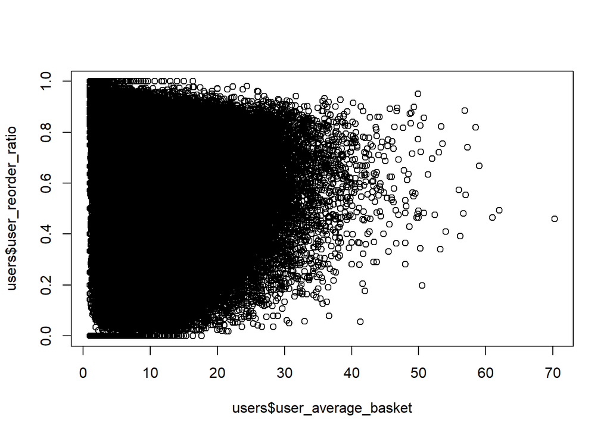

```r
plot( users$user_average_basket, users$user_reorder_ratio)
```

# add order_id from train/test

```r
orders_tmp = head( orders, n = 50)
```

```r
us <- orders %>%
  filter(eval_set != "prior") %>%
  select(user_id, order_id, eval_set,
         days_since_last_order = days_since_prior_order
         )

users <- users %>% inner_join(us)
rm(us)
gc()
```

```
##             used   (Mb) gc trigger   (Mb)  max used   (Mb)
## Ncells    494320   26.4   12857744  686.7  20885653 1115.5
## Vcells 198118835 1511.6  546300755 4168.0 706506574 5390.3
```

```r
users_tmp2 = head( users, n = 50)
```

# Database —————————————————————-

### create features

- up_orders: how many times a product_id was ordered by user_id
- up_first_order: in which order a product_id was first ordered
- up_last_order: in which order a product_id was last ordered

```r
data <- orders_products %>%
  group_by(user_id, product_id) %>%
  summarise(
    up_orders = n(),
    up_first_order = min(order_number),
    up_last_order  = max(order_number),
    up_average_cart_position = mean(add_to_cart_order)
  )

data_tmp = head( data, n = 250 )


rm(orders_products, orders)
```

```r
data <- data %>%
  inner_join(prd, by = "product_id") %>%
  inner_join(users, by = "user_id")

data_tmp1 = head( data, n = 250 )
```

### create features

- up_order_rate: user-specific order intensity of a product_id : proportion of times a product_id was ordered in total number of orders
- up_orders_since_last_order: how many orders ago a product was last ordered
- up_order_rate_since_first_order: product-specific order intensity over the time between a product was first ordered and the last order

```r
data$up_order_rate                   <- data$up_orders / data$user_orders
data$up_orders_since_last_order      <- data$user_orders - data$up_last_order
data$up_order_rate_since_first_order <- data$up_orders / (data$user_orders - data$up_first_order + 1)

data_tmp2 = head( data, n = 250 )
```

# add train

```r
data <- data %>%
  left_join(ordert %>% select(user_id, product_id, reordered),
            by = c("user_id", "product_id"))

data_tmp3 = head( data, n = 250 )

rm(ordert, prd, users)
gc()
```

```
##             used   (Mb) gc trigger   (Mb)  max used   (Mb)
## Ncells    494679   26.5    9524812  508.7  20885653 1115.5
## Vcells 233636625 1782.6  655640906 5002.2 706506574 5390.3
```

## there are no labels ‘prior’ in data

```r
data_prior = data %>% filter( eval_set == "prior")
data_train = data %>% filter( eval_set == "train")
data_test  = data %>% filter( eval_set == "test")

dim( data_prior )
```

```
## [1]  0 24
```

```r
dim( data_train )
```

```
## [1] 8474661      24
```

```r
dim( data_test )
```

```
## [1] 4833292      24
```

```r
#ordert_user_id_1 = ordert %>% filter( user_id == 1 ) %>% arrange( product_id )
```

# Train / Test datasets —————————————————

```r
train <- as.data.frame(data[data$eval_set == "train",])
train$eval_set <- NULL
train$user_id <- NULL
train$product_id <- NULL
train$order_id <- NULL
train$reordered[is.na(train$reordered)] <- 0

train_tmp = head( train, n = 250 )

test <- as.data.frame(data[data$eval_set == "test",])
test$eval_set <- NULL
test$user_id <- NULL
test$reordered <- NULL
#NB! keep order_id and product_id: use later to predict the basket

test_tmp = head( test, n = 250 )

rm(data)
gc()
```

```
##             used   (Mb) gc trigger   (Mb)  max used   (Mb)
## Ncells    701403   37.5    4876703  260.5  20885653 1115.5
## Vcells 453863084 3462.8  944298904 7204.5 786335043 5999.3
```

```r
dim( train )
```

```
## [1] 8474661      20
```

```r
colnames( train )
```

```
##  [1] "up_orders"                       "up_first_order"
##  [3] "up_last_order"                   "up_average_cart_position"
##  [5] "prod_orders"                     "prod_reorder_probability"
##  [7] "prod_reorder_times"              "prod_reorder_ratio"
##  [9] "user_orders"                     "user_period"
## [11] "user_mean_days_since_prior"      "user_total_products"
## [13] "user_reorder_ratio"              "user_distinct_products"
## [15] "user_average_basket"             "days_since_last_order"
## [17] "up_order_rate"                   "up_orders_since_last_order"
## [19] "up_order_rate_since_first_order" "reordered"
```

```r
dim( test )
```

```
## [1] 4833292      21
```

```r
colnames( test )
```

```
##  [1] "product_id"                      "up_orders"
##  [3] "up_first_order"                  "up_last_order"
##  [5] "up_average_cart_position"        "prod_orders"
##  [7] "prod_reorder_probability"        "prod_reorder_times"
##  [9] "prod_reorder_ratio"              "user_orders"
## [11] "user_period"                     "user_mean_days_since_prior"
## [13] "user_total_products"             "user_reorder_ratio"
## [15] "user_distinct_products"          "user_average_basket"
## [17] "order_id"                        "days_since_last_order"
## [19] "up_order_rate"                   "up_orders_since_last_order"
## [21] "up_order_rate_since_first_order"
```

```r
library(xgboost)
library(Ckmeans.1d.dp)
params <- list(
  "objective"           = "reg:logistic",
  "eval_metric"         = "logloss", # rmse
  "eta"                 = 0.2,
  "max_depth"           = 5,
  "min_child_weight"    = 1,  #10
  "gamma"               = 0.70,
  "subsample"           = 0.77,
  "colsample_bytree"    = 0.95,
  "alpha"               = 2e-05,
  "lambda"              = 6 #10
)

subtrain <- train %>% sample_frac(0.15)
subtrain_tmp = head(subtrain, n = 100)

ch_stdn_data <- FALSE

if( ch_stdn_data ){

  # standardize features in subtrain set
  subtrain_mat      = as.matrix(subtrain %>% select(-reordered) )
  subtrain_mat_stnd = scale( subtrain_mat ); rm( subtrain_mat )
  X                 = xgb.DMatrix(subtrain_mat_stnd, label = subtrain$reordered ); rm( subtrain_mat_stnd )

}else{

  X = xgb.DMatrix( as.matrix(subtrain %>% select(-reordered) ), label = subtrain$reordered );

}


if(FALSE){
  cv <- xgb.cv(data = X, params = params, nrounds =100, nthread = 8, nfold = 5)
}
```

```r
model = xgboost(data = X, params = params, nrounds = 100, nthread = 8)
```

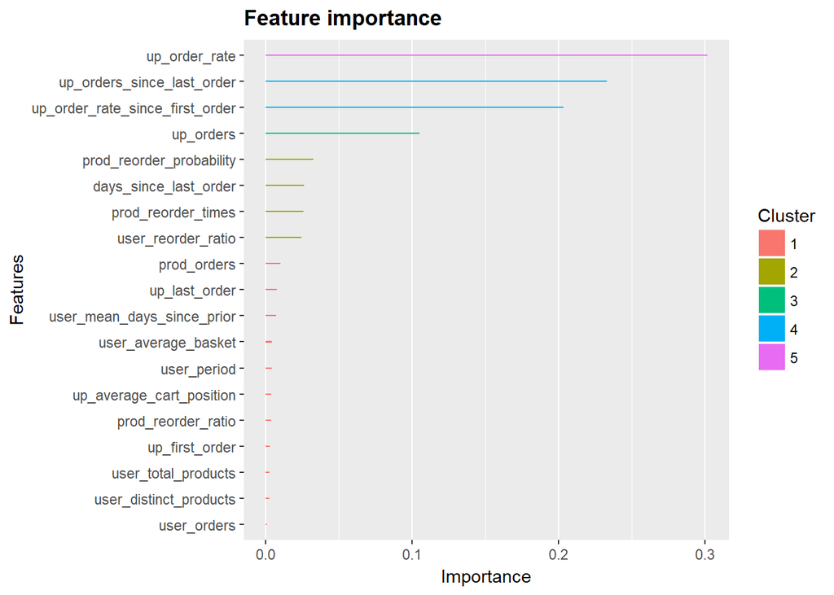

```r
importance <- xgb.importance(colnames(X), model = model)
xgb.ggplot.importance(importance)
```

```r
rm(X, importance, subtrain)
gc()
```

```
##             used   (Mb) gc trigger   (Mb)  max used   (Mb)
## Ncells   1541195   82.4    4876703  260.5  20885653 1115.5
## Vcells 455343667 3474.0  944298904 7204.5 786335043 5999.3
```

# Predict with model ————————————————————-

```r
#rm( train )
if( ch_stdn_data ){

   X <- xgb.DMatrix( scale( as.matrix(test %>% select(-order_id, -product_id)) ) )

}else{

   X <- xgb.DMatrix( as.matrix(test %>% select(-order_id, -product_id) ) )

}


test$reordered <- predict(model, X)

test_tmp1 = head( test, n = 250 )
```

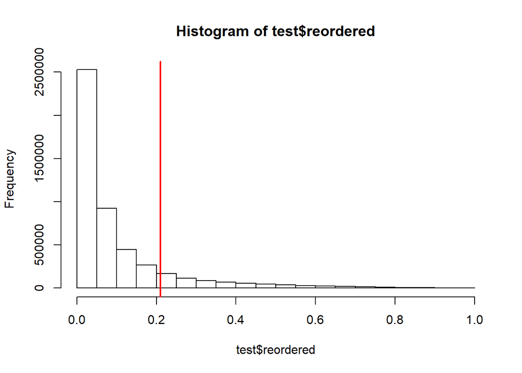

```r
cutoff = 0.21

hist( test$reordered )
abline( v = cutoff , col = 2, lwd = 2)
```

```r
mean( test$reordered > cutoff )
```

```
## [1] 0.1303766
```

```r
test_1st <- test %>%
            group_by( order_id ) %>%
            summarise(
            #pred_prob_reorder = median(   reordered)              #08
            #pred_prob_reorder = quantile( reordered, 0.75)        #09
            #pred_prob_reorder = quantile( reordered, 0.85)        #10
            #pred_prob_reorder = quantile( reordered, 0.75) + 0.1  #11
             pred_prob_reorder = quantile( reordered, 0.5) + 0.15  #12 LB 0.369

     )
test_1st_tmp = head( test_1st, n = 250 )
```

```r
test_2nd <- test_1st %>%
            left_join( test, by = "order_id")

test_2nd_tmp = head( test_2nd, n = 250 )

test_2nd$reordered_in = ( test_2nd$reordered > test_2nd$pred_prob_reorder) * 1
#test_2nd$reordered_in = ( test_2nd$reordered > cutoff) * 1

test_2nd_tmp1 = head( test_2nd, n = 250 )

#compute predicted average basket size
pred_basket <- test_2nd %>%
              group_by( order_id ) %>%
              summarise(
                pred_basket_size = sum( reordered_in )
              )
pred_basket_tmp = head( pred_basket, n = 20 )

summary( pred_basket_tmp$pred_basket_size )
```

```
##    Min. 1st Qu.  Median    Mean 3rd Qu.    Max.
##    0.00    2.50    9.00   10.35   14.25   35.00
```

```r
submission <- test_2nd %>%
  filter(reordered_in == 1) %>%
  group_by(order_id) %>%
  summarise(
    products = paste(product_id, collapse = " ")
  )

submission_tmp = head( submission, n = 250 )

missing <- data.frame(
  order_id = unique(test$order_id[!test$order_id %in% submission$order_id]),
  products = "None"
)

submission <- submission %>% bind_rows(missing) %>% arrange(order_id)

submission_tmp = head( submission, n = 250 )

write.csv(submission, file = paste0( path_subm,"submit12_pred.csv"), row.names = F)
```